# 100 Years of Baby Names in the United States

Hayden Miller

December 3, 2024

## Introduction

The Social Security Administration provides a comprehensive list of annual baby name counts by state in the US, sourced from social security card applications. We'll explore this data and search for interesting trends as a means of demonstrating the data science process. What are the most popular names of all time? Are names growing more diverse? Are male and female names distributed differently? Can we predict where name trends are headed? We'll examine all of these questions in detail.

## Loading the Data

We begin with the relevant imports:

```python
import random
from pathlib import Path
import matplotlib.pyplot as plt
import numpy as np
import pandas as pd
import scipy
from sklearn.linear_model import LinearRegression
from sklearn.metrics import mean_squared_error
from sklearn.model_selection import train_test_split
from sklearn.preprocessing import MinMaxScaler, StandardScaler
from torch import nn, Tensor, from_numpy, manual_seed
from torch.optim import Adam
from torch.utils.data import DataLoader, TensorDataset
```

Let's also set the random seed to make results consistent:

```python
np.random.seed(0)
random.seed(0)
manual_seed(0)
```

```
<torch._C.Generator at 0x78350899e0d0>
```

Now, let's load the data into a pandas DataFrame. I'm using the state-specific and territory-specific data on US baby names from https://www.ssa.gov/oact/babynames/limits.html. This data is grouped into 53 CSV files (with the "TXT" extension), each corresponding to a single state or territory*. After extracting all of these files into a "names" folder, the following code will load it all into a DataFrame:

```python
names_path = Path("./names")
column_names = ["Region", "Gender", "Year", "Name", "Occurrences"]
names_dfs = (pd.read_csv(f, names=column_names) for f in names_path.iterdir())
names_df = pd.concat(names_dfs)

# Reset index because otherwise we'll just be concatenating the indices from all
# the different dataframes, and we want a unique index for each entry

# drop=True means we ignore the old indices rather than creating a new "index" column
names_df = names_df.reset_index(drop=True)
names_df
```

|  | Region | Gender | Year | Name | Occurrences |
| --- | --- | --- | --- | --- | --- |
| 0 | DC | F | 1910 | Mary | 80 |
| 1 | DC | F | 1910 | Margaret | 72 |
| 2 | DC | F | 1910 | Helen | 52 |
| 3 | DC | F | 1910 | Dorothy | 50 |
| 4 | DC | F | 1910 | Elizabeth | 34 |
| ... | ... | ... | ... | ... | ... |
| 6531651 | NY | M | 2023 | Zephaniah | 5 |
| 6531652 | NY | M | 2023 | Zisha | 5 |
| 6531653 | NY | M | 2023 | Zishe | 5 |
| 6531654 | NY | M | 2023 | Zubayr | 5 |
| 6531655 | NY | M | 2023 | Zymir | 5 |

6531656 rows × 5 columns

*Some low-population territories (American Samoa, Guam, Northern Mariana Islands, and the U.S. Virgin Islands) are treated as a single combined territory labeled "TR" in this dataset. The other two non-state territories are Puerto Rico (PR) and Washington, D.C. (DC).

# Exploration

One thing that's immediately worth noting about this data is that it's missing all names with less than 5 occurrences for a given year (for privacy, according to the source). With that in mind, let's see how much of the US population is represented here. [According to the CDC](https://www.cdc.gov/nchs/products/databriefs/db507.htm), 3,596,017 births were registered in the United States in 2023. Comparing this to the number of names we have for that year:

```python
annual_occurrences = names_df.groupby("Year")["Occurrences"].sum()
annual_occurrences[2023] / 3596017
```

```
0.7665842514092676
```

It seems like the majority of the population is represented. Let's also graph this estimate over time to verify that the curve looks reasonable and there aren't any missing years or unexpected outliers:

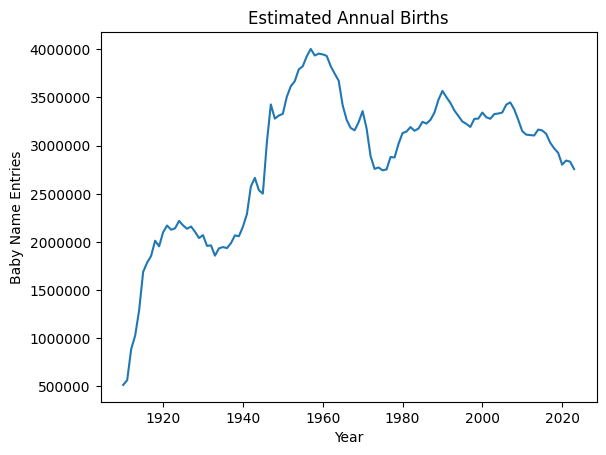

```python
fig, ax = plt.subplots()
cax = ax.plot(annual_occurrences.index, annual_occurrences)
ax.ticklabel_format(style="plain")
ax.set_title("Estimated Annual Births")
ax.set_xlabel("Year")
ax.set_ylabel("Baby Name Entries")
plt.show()
```

This appears mostly consistent with [historical birth rates](https://si.wsj.net/public/resources/images/OG-FY290_BIRTHS_4U_20210505100753.png) (source: Wall Street Journal, which itself cites the CDC). However, it's worth noting that some of the earlier years don't have as much data. Recall that this data is based on Social Security card applications. According to [the source](https://www.ssa.gov/oact/babynames/background.html), "many people born before 1937 never applied for a Social Security card", meaning they are excluded. To handle this, we'll ensure that our calculations always account for the total number of data points in a given year (which is desirable anyway, since we won't want population to be a confounding variable in any of our analysis).

Let's add a new column to our dataframe to do this:

```python
def calc_proportion(df):
  df_annual_occurrences = df.groupby("Year")["Occurrences"].sum()
  annual_per_row = df_annual_occurrences[df["Year"]]
  annual_per_row.index = df.index
  return df["Occurrences"] / annual_per_row

# For a given year, the Proportion column has a given name's occurences in a given state as a proportion of that year's national birth count.
names_df["Proportion"] = calc_proportion(names_df)
names_df
```

|  | Region | Gender | Year | Name | Occurrences | Proportion |
| --- | --- | --- | --- | --- | --- | --- |
| 0 | DC | F | 1910 | Mary | 80 | 0.000155 |
| 1 | DC | F | 1910 | Margaret | 72 | 0.000139 |
| 2 | DC | F | 1910 | Helen | 52 | 0.000101 |
| 3 | DC | F | 1910 | Dorothy | 50 | 0.000097 |
| 4 | DC | F | 1910 | Elizabeth | 34 | 0.000066 |
| ... | ... | ... | ... | ... | ... | ... |
| 6531651 | NY | M | 2023 | Zephaniah | 5 | 0.000002 |
| 6531652 | NY | M | 2023 | Zisha | 5 | 0.000002 |
| 6531653 | NY | M | 2023 | Zishe | 5 | 0.000002 |
| 6531654 | NY | M | 2023 | Zubayr | 5 | 0.000002 |
| 6531655 | NY | M | 2023 | Zymir | 5 | 0.000002 |

6531656 rows × 6 columns

Now, let's find out the most popular baby names of all time by average proportion of annual births. We use this metric so that popular names during periods of high births aren't favored over others:

```python
num_years = len(names_df.groupby("Year"))
# Add up the proportions for each state (and each year), then divide by the number of years to get the annual average
average_annual_proportions = names_df.groupby("Name")["Proportion"].sum().sort_values(ascending=False) / num_years
top_10_average_annual_proportions = average_annual_proportions.head(10)
top_10_average_annual_proportions
```

| Name | Proportion |
| --- | --- |
| James | 0.016461 |
| John | 0.016318 |
| Robert | 0.015538 |
| Mary | 0.014097 |
| William | 0.013294 |
| Michael | 0.012010 |
| David | 0.010267 |
| Joseph | 0.008268 |
| Richard | 0.008038 |
| Charles | 0.007853 |

**dtype:** float64

It looks like the most popular name of all time by this metric is James: for any given year, you can expect that about 1.6% of new babies (on average) will be named James.

We can also graph these proportions over time to see how these 10 names have shifted in popularity:

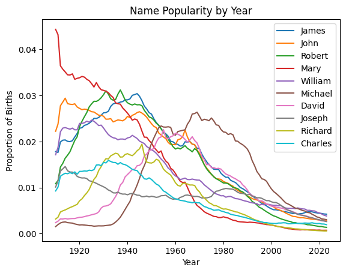

```python
nationwide_proportions = names_df.groupby(["Name", "Year"])["Proportion"].sum()
fig, ax = plt.subplots()
ax.set_title("Name Popularity by Year")
ax.set_xlabel("Year")
ax.set_ylabel("Proportion of Births")
for name in top_10_average_annual_proportions.index:
    name_proportions = nationwide_proportions[name]
    ax.plot(name_proportions.index, name_proportions, label=name)
ax.legend()
plt.show()
```

Interestingly, all of these names are clearly on the decline. This may be an artifact of the method used to evaluate popularity; it seems reasonable to assume that names which have been around for a long time and have already hit their peak would have an advantage over names which weren't popular until more recently. However, this could also be taken as a sign that names are growing more diverse, decreasing the ability for a select few to dominate. Let's test this hypothesis.

First, we'll need a measure of name diversity. For a given year, we'll define this as the minimal number of names whose proportions for that year add up to 50%. Let's get that for every year:

```python
def calc_diversity(groups):
  diversity = []
  years = []
  for (year, year_data) in groups:
    in_top_20_percent = year_data.sort_values(ascending=False).cumsum() < .5
    diversity.append(in_top_20_percent.sum())
    years.append(year)
  return pd.Series(diversity, years)

diversity = calc_diversity(names_df.groupby(["Year", "Name"])["Proportion"].sum().groupby("Year"))
diversity
```

|  | 0 |
| --- | --- |
| 1910 | 57 |
| 1911 | 57 |
| 1912 | 62 |
| 1913 | 62 |
| 1914 | 64 |
| ... | ... |
| 2019 | 249 |
| 2020 | 256 |
| 2021 | 262 |
| 2022 | 271 |
| 2023 | 277 |

114 rows × 1 columns

**dtype:** int64

Now, we can plot this data:

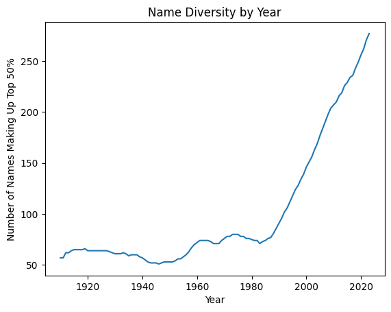

```python
fig, ax = plt.subplots()
cax = ax.plot(diversity.index, diversity)
ax.ticklabel_format(style="plain")
ax.set_title("Name Diversity by Year")
ax.set_xlabel("Year")
ax.set_ylabel("Number of Names Making Up Top 50%")
plt.show()
```

Clearly, name diversity is on the rise. We can also demonstrate this by testing for correlation (between diversity and year) and verifying that it's significant:

```python
diversity.corr(diversity.index.to_series())
```

```
0.8114902746969344
```

Now, let's go back and take a different turn to explore something else. The sum of the top 10 names' average proportions should be the probability that a baby's name in any given year will be in this list:

```python
top_10_average_annual_proportions.sum()
```

```
0.12214498590401628
```

This probability is quite significant: 12%. However, only one of these names (Mary) is female, and it accounted for just 1.4% of this total (see the above table). Does this mean that male names are disproportionally represented in our data? Let's find out:

```python
gender_occurrences = names_df.groupby("Gender")["Occurrences"].sum()
gender_occurrences["M"] / gender_occurrences.sum()
```

```
0.5202506411325489
```

52% of our names are male, which hardly explains this phenomenon. In that case, another question is raised: are female names just more diverse? Let's test this. Our null hypothesis will be that male & female diversities are distributed the same. Here, we calculate and graph the diversities separately:

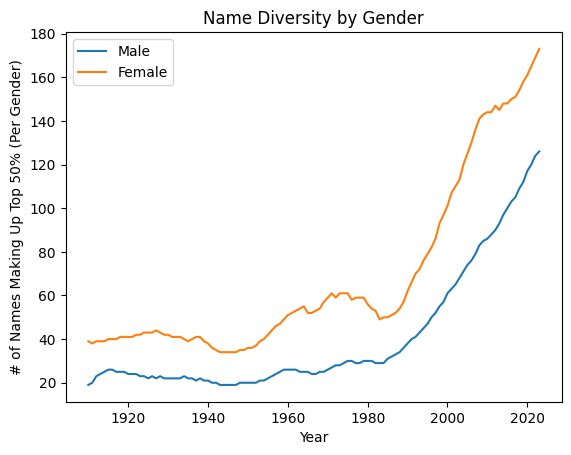

```python
fig, ax = plt.subplots()
ax.set_title("Name Diversity by Gender")
ax.set_xlabel("Year")
ax.set_ylabel("# of Names Making Up Top 50% (Per Gender)")

gender_diversities = []

# Note that we recalculate the proportions to be male/female-specific
for (gender, label) in (("M", "Male"), ("F", "Female")):
  gender_df = names_df[names_df["Gender"] == gender]
  gender_df.loc[:,"Proportion"] = calc_proportion(gender_df)
  gender_diversity = calc_diversity(gender_df.groupby(["Year", "Name"])["Proportion"].sum().groupby("Year"))
  gender_diversities.append(gender_diversity)
  ax.plot(gender_diversity.index, gender_diversity, label=label)

ax.legend()
plt.show()
```

Looks like they're different! We can validate this with a statistical test - namely, a paired T test:

```python
scipy.stats.ttest_rel(*gender_diversities).pvalue
```

```
3.26173483289171e-45
```

The extremely low p value here indicates to reject the null hypothesis (this would be true for any reasonable alpha value we could've chosen), meaning that male and female names are indeed distributed differently, which lines up with what we can see in the graph above and what we predicted earlier.

# Making Predictions

Now that we've gotten a feel for our data, let's go back to one of our initial questions: can we predict future trends based on existing data?

We'll tackle this with a neural network. The goal is that we'll be able to input the annual occurrences for some name, and get a list of predicted data points that extend this data into the future.

For the sake of speed, we'll rely on the top 1000 names for training, but you can experiment with changing this value and see if it impacts the results. The first thing we'll do is filter our dataset to include only these names:

```python
name_occurrences = names_df.groupby("Name")["Occurrences"].sum()
top_n_names = 1000
common_names = name_occurrences.index[name_occurrences.isin(name_occurrences.sort_values(ascending=False)[:top_n_names])]
filtered_names_df = names_df[names_df["Name"].isin(common_names)]
```

Next, we'll prepare our training data. Recall that we want a list of (annual) occurrences for each name. We'll use the [pivot_table](https://pandas.pydata.org/docs/reference/api/pandas.pivot_table.html) function in pandas to reshape our data into this format.

This model will make predictions up to 20 years into the future, but that's another hyperparameter that you can feel free to tweak. We also scale our data to a range of 0-1 here, in order to make the (otherwise very large) values easier to work with.

```python
pivot = pd.pivot_table(names_df, values="Occurrences", index=["Name"], columns=["Year"], aggfunc="sum", fill_value=0)
# axis=None means we get max for the whole table rather than per-column
# this is effectively min-max scaling for the entire table; note that the min is always 0 since occurrences can't be negative
scale_factor = pivot.max(axis=None)
pivot_scaled = pivot / scale_factor
pivot_filtered = pivot.loc[common_names]
pivot_filtered_scaled = pivot_scaled.loc[common_names]
predicting_n_years = 20
first_predicted_year = 2024 - predicting_n_years
# Y (the expected output) is the data for the last n years; X has everything before that
X = pivot_filtered_scaled.loc[:, :first_predicted_year]
Y = pivot_filtered_scaled.loc[:, first_predicted_year:]
display(X.head())
display(Y.head())
```

| Year Name | 1910 | 1911 | 1912 | 1913 | 1914 | 1915 | 1916 | 1917 | 1918 | 1919 | ... | 1995 | 1996 | 1997 | 1998 | 1999 | 2000 | 2001 | 2002 | 2003 | 2004 |
| --- | --- | --- | --- | --- | --- | --- | --- | --- | --- | --- | --- | --- | --- | --- | --- | --- | --- | --- | --- | --- | --- |
| Aaliyah | 0.000000 | 0.000000 | 0.000000 | 0.000000 | 0.000000 | 0.000000 | 0.000000 | 0.000000 | 0.000000 | 0.000000 | ... | 0.012309 | 0.008032 | 0.017096 | 0.013831 | 0.010596 | 0.014682 | 0.033861 | 0.048283 | 0.037016 | 0.035103 |
| Aaron | 0.001112 | 0.001432 | 0.002594 | 0.003746 | 0.004567 | 0.005218 | 0.005628 | 0.005769 | 0.006209 | 0.006099 | ... | 0.133421 | 0.120151 | 0.112109 | 0.106100 | 0.098989 | 0.095975 | 0.096005 | 0.090627 | 0.089245 | 0.084768 |
| Abby | 0.000000 | 0.000000 | 0.000000 | 0.000000 | 0.000000 | 0.000000 | 0.000000 | 0.000000 | 0.000000 | 0.000000 | ... | 0.013691 | 0.014061 | 0.015553 | 0.015914 | 0.017907 | 0.015574 | 0.019740 | 0.019550 | 0.020361 | 0.020271 |
| Abel | 0.000000 | 0.000070 | 0.000100 | 0.000200 | 0.000150 | 0.000240 | 0.000411 | 0.000571 | 0.000541 | 0.000371 | ... | 0.006670 | 0.005679 | 0.006640 | 0.006380 | 0.006870 | 0.007281 | 0.007171 | 0.007511 | 0.007281 | 0.007752 |
| Abigail | 0.000000 | 0.000000 | 0.000000 | 0.000000 | 0.000000 | 0.000060 | 0.000100 | 0.000090 | 0.000000 | 0.000000 | ... | 0.078358 | 0.086170 | 0.096426 | 0.111588 | 0.117568 | 0.131599 | 0.148604 | 0.153592 | 0.159841 | 0.155455 |

5 rows × 95 columns

| Year Name | 2004 | 2005 | 2006 | 2007 | 2008 | 2009 | 2010 | 2011 | 2012 | 2013 | 2014 | 2015 | 2016 | 2017 | 2018 | 2019 | 2020 | 2021 | 2022 | 2023 |
| --- | --- | --- | --- | --- | --- | --- | --- | --- | --- | --- | --- | --- | --- | --- | --- | --- | --- | --- | --- | --- |
| Aaliyah | 0.035103 | 0.034642 | 0.037627 | 0.039760 | 0.040611 | 0.043966 | 0.046911 | 0.051478 | 0.055404 | 0.052609 | 0.049154 | 0.048964 | 0.046620 | 0.041983 | 0.038448 | 0.036766 | 0.035664 | 0.036115 | 0.032689 | 0.028473 |
| Aaron | 0.084768 | 0.078368 | 0.083416 | 0.089806 | 0.085870 | 0.080211 | 0.075053 | 0.076636 | 0.076065 | 0.073641 | 0.074653 | 0.072479 | 0.072630 | 0.073040 | 0.060632 | 0.056135 | 0.051718 | 0.049014 | 0.045659 | 0.046120 |
| Abby | 0.020271 | 0.017416 | 0.016755 | 0.015684 | 0.013080 | 0.012599 | 0.011227 | 0.010436 | 0.010125 | 0.008793 | 0.008182 | 0.006930 | 0.007041 | 0.006740 | 0.006269 | 0.005829 | 0.005659 | 0.004817 | 0.004787 | 0.004437 |
| Abel | 0.007752 | 0.008232 | 0.009034 | 0.009154 | 0.008423 | 0.009444 | 0.011187 | 0.014953 | 0.019509 | 0.022464 | 0.025829 | 0.032549 | 0.030486 | 0.027101 | 0.026831 | 0.024567 | 0.021252 | 0.019439 | 0.017486 | 0.016385 |
| Abigail | 0.155455 | 0.158199 | 0.156897 | 0.155244 | 0.151479 | 0.144448 | 0.143096 | 0.133031 | 0.127743 | 0.124738 | 0.121574 | 0.124748 | 0.118389 | 0.106901 | 0.099130 | 0.092159 | 0.079390 | 0.069986 | 0.063145 | 0.056896 |

```python
in_features = len(X.columns)
out_features = len(Y.columns)

model = nn.Sequential(
    nn.Linear(in_features, in_features),
    nn.ReLU(),
    nn.Linear(in_features, in_features),
    nn.ReLU(),
    nn.Linear(in_features, out_features),
)
```

Then, we'll split our data into training & testing subsets using scikit-learn's [train_test_split](https://scikit-learn.org/stable/modules/generated/sklearn.model_selection.train_test_split.html) function, and prepare it for use with our model (see [Datasets & DataLoaders](https://pytorch.org/tutorials/beginner/basics/data_tutorial.html)):

```python
def create_loader(x, y):
  return DataLoader(TensorDataset(Tensor(x.to_numpy()), Tensor(y.to_numpy())), batch_size=32, shuffle=True)

X_train, X_test, Y_train, Y_test = train_test_split(X, Y, test_size=0.2)
train_loader = create_loader(X_train, Y_train)
test_loader = create_loader(X_test, Y_test)
```

Now, it's time for training. We'll do this with a [training loop](https://pytorch.org/tutorials/beginner/introyt/trainingyt.html#the-training-loop) that aims to minimize the mean squared error:

```python
criterion = nn.MSELoss()
optimizer = Adam(model.parameters(), lr=0.0001)
epochs = 100
losses = []
for epoch in range(epochs):
    running_loss = 0.0
    for data, targets in train_loader:
        # Forward pass
        pred = model(data)
        loss = criterion(pred, targets)
        # Backward pass
        loss.backward()
        optimizer.step()
        optimizer.zero_grad()
    losses.append(loss.item())
    print(f'Epoch {epoch+1}/{epochs}, Loss: {loss.item()}')
```

[output not shown]

Let's plot the losses computed during training to see how the model improved:

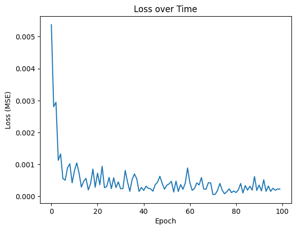

```python
fig, ax = plt.subplots()
cax = ax.plot(losses)
ax.ticklabel_format(style="plain")
ax.set_title("Loss over Time")
ax.set_xlabel("Epoch")
ax.set_ylabel("Loss (MSE)")
ax.xaxis.get_major_locator().set_params(integer=True)
plt.show()
```

Looks good! Now, let's visualize some predictions. By applying our model to actual data from at least 20 years ago, we can compare its predictions to the real thing. Let's do this for a few of the most common names:

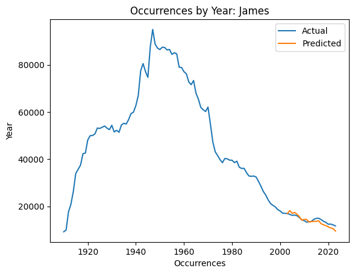

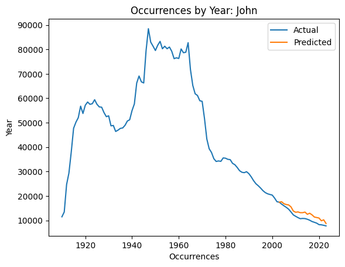

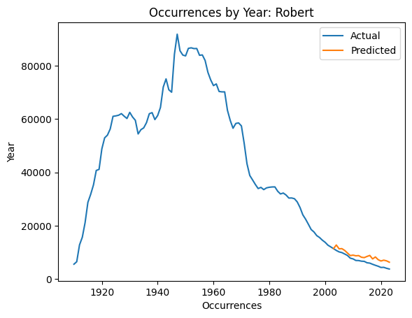

```python
def predict(name, first_predicted_year):
  start_year = first_predicted_year - in_features
  x = pivot_scaled.loc[[name], start_year:first_predicted_year]
  x_tensor = Tensor(x.to_numpy())
  pred = model(x_tensor).detach() * scale_factor
  predicted_years = list(range(first_predicted_year, first_predicted_year + predicting_n_years))
  pred = pd.DataFrame(pred, columns=predicted_years).transpose()[0]
  # Add the last real point from the X values, for prettier graphing
  # (This visually connects the real & predicted data)
  last_real_point = pivot.loc[name, [first_predicted_year - 1]]
  pred = pd.concat([last_real_point, pred])
  return pred

def graph_prediction(name, first_predicted_year):
  fig, ax = plt.subplots()
  ax.ticklabel_format(style="plain")
  ax.set_title("Occurrences by Year: " + name)
  ax.set_xlabel("Occurrences")
  ax.set_ylabel("Year")
  ax.plot(pivot.loc[name], label="Actual")
  ax.plot(predict(name, first_predicted_year), label="Predicted")
  ax.legend()
  plt.show()

for name in top_10_average_annual_proportions.index[:3]:
  graph_prediction(name, first_predicted_year)
```

Not perfect (which seems reasonable given the variety of factors that can affect name trends), but our model seems pretty close. Now that we have it, we can also make predictions about the future. Let's find out which names are predicted to be most popular 20 years from now by making predictions for all of the names:

```
Index(['Theodore', 'Mateo', 'Luna', 'Charlotte', 'Oliver', 'Maverick', 'Luca',
       'Liam', 'Ezra', 'Nova',
       ...
       'Crystal', 'Gregory', 'Stephanie', 'Steven', 'Justin', 'Mary', 'Amanda',
       'Brandon', 'Jessica', 'Lisa'],
      dtype='object', name='Name', length=34149)
```

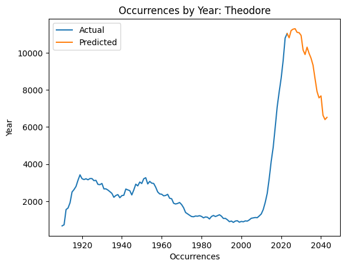

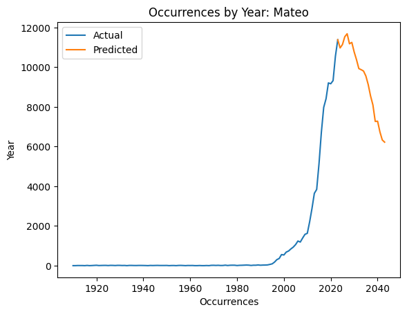

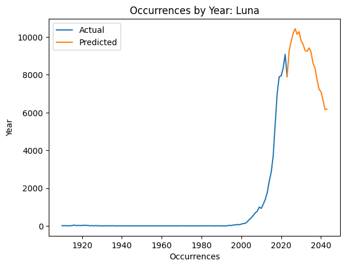

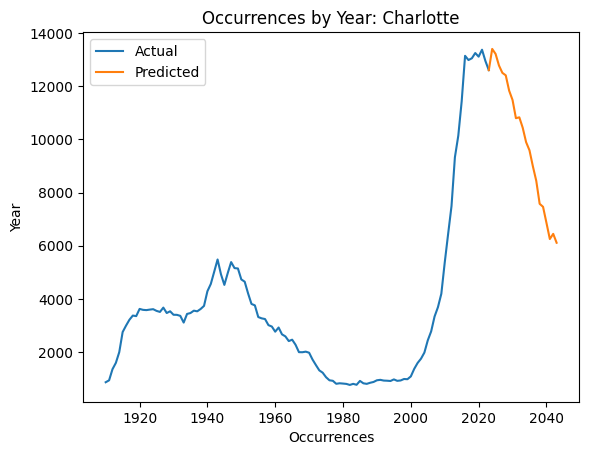

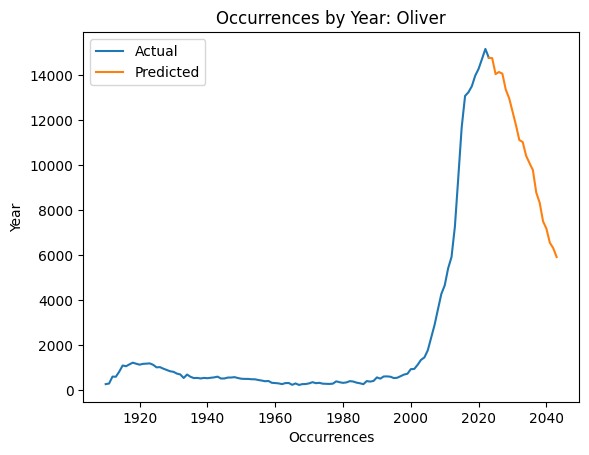

```python
start_year = 1910 + predicting_n_years - 1
all_predictions = model(Tensor(pivot_scaled.loc[:, start_year:].to_numpy())).detach().numpy() * scale_factor
most_popular_future = pivot.index[all_predictions[:, -1].argsort()[::-1]]
display(most_popular_future)
for name in most_popular_future[:5]:
  graph_prediction(name, 2024)
```

Interestingly, most of these names are on the rise, but predicted to peak before the end of the 20-year period, while we would've expected these names to peak at the end. If we wanted to take this further, we might ask why this would be (perhaps we should've trained on some less common names, too), and this could be another avenue to explore. However, for the purposes of this tutorial, we'll stop here.

# Conclusion

There's a surprising amount of complexity hidden in baby name trends. We've learned that names are growing more diverse. Female names have always been the most diverse, though "Mary" was initially more common than any other name. We've seen the most popular names of all time, and some potential candidates for the most popular in 20 years' time. We've seen the full data science process, from exploratory data analysis to machine learning, and I hope you've picked up some tips that you'll be able to apply in your own endeavors along the way. Thanks for reading!